# Seasonal Autoregressive Integrated Moving Average Process

- **참고 : Statistics and Data Analysis for Financial Engineering**

**By Yeong Eun Jeon and Jung In Seo**

Version : R-4.3.0 in Window

# **Contents**

- Hstarts 데이터셋
- AirPassengers 데이터셋

# **1. Hstarts 데이터셋**

Package `"Ecdat"`에서 제공하는 Hstarts 데이터셋은 1960년 1분기부터 2001년 4분기까지 캐나다의 분기별 도시 주택 착공 건수의 로그값이다.

```r
# 데이터 불러오기
data(Hstarts, package = "Ecdat")
Hstarts
```

```
##               hs    hssa
## 1960 Q1  7.98933      NA
## 1960 Q2  8.83961      NA
## 1960 Q3  8.94841      NA
## 1960 Q4  8.98907      NA
## 1961 Q1  8.39087      NA
## 1961 Q2  9.09204      NA
## 1961 Q3  9.12005      NA
## 1961 Q4  9.04617      NA
## 1962 Q1  8.41013      NA
## 1962 Q2  9.22375      NA
## 1962 Q3  9.21443      NA
## 1962 Q4  9.14145      NA
## 1963 Q1  8.45105      NA
## 1963 Q2  9.27685      NA
```

[output cut: 154 more lines]

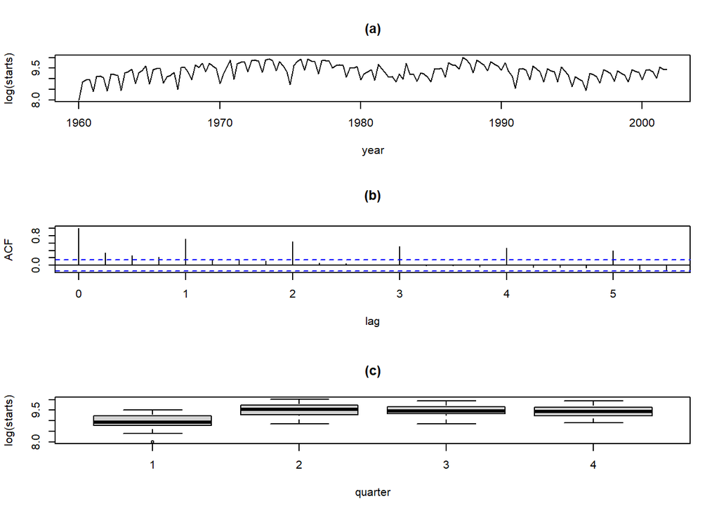

```r
x <- ts(Hstarts[,1],
        start = 1960,               # 시계열 시작 날짜
        frequency = 4)              # 분기별 시계열로 1년에 4번 관측

par(mfrow=c(3,1))                   # 3개의 그래프를 한 화면에 출력
# 시계열 그림
plot(x,
     xlab = "year", ylab = "log(starts)",
     type = "l",                    # 선으로 표시
     main="(a)")
# 자기상관계수 그림
acf(x,
    main = "(b)",
    xlab = "lag")
# 분기별 상자그림
quart = rep(1:4, 42)                # 분기
boxplot(x ~ quart,
        xlab = "quarter", ylab = "log(starts)",
        main = "(c)")
```

`Result!` (a) 그래프를 통해 해당 시계열은 계절성이 강하다는 것을 알 수 있다.  
(b) 그래프를 통해 4의 배수인 시차에서는 자기상관이 크며, 다른 시차에서는 천천히 0으로 감소한다는 것을 알 수 있다.  
(c) 그래프를 통해 해당 시계열의 관측값은 1분기에 가장 낮으며, 2분기에는 높다는 것을 알 수 있다.

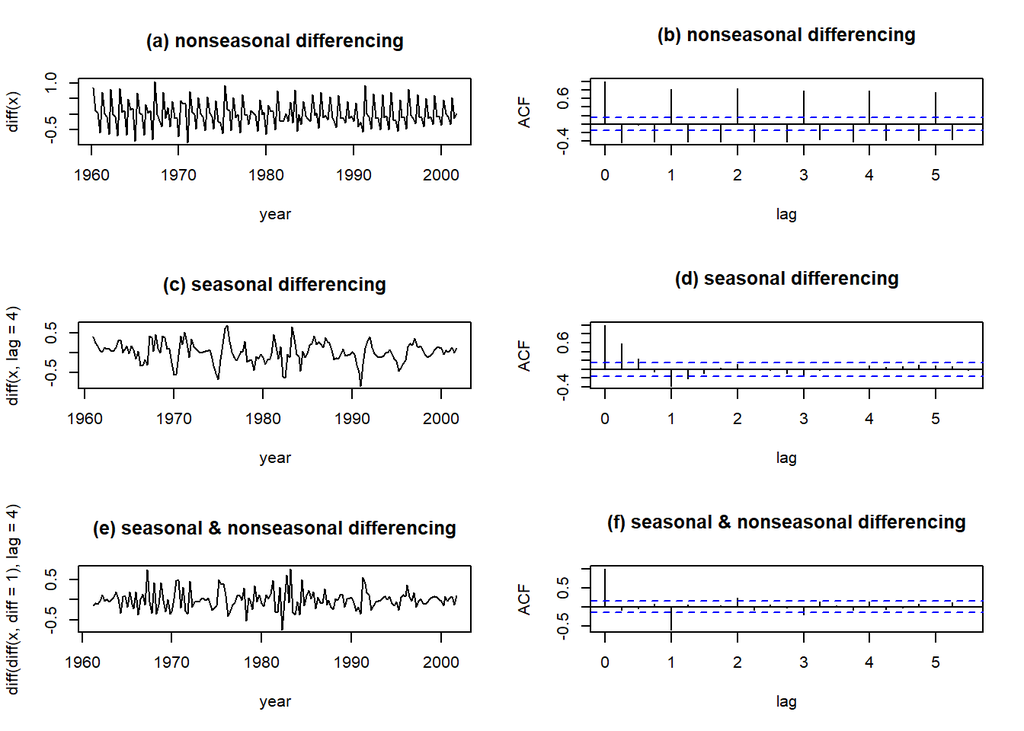

```r
par(mfrow=c(3,2))                      # 한 행에 2개의 그래프를 출력 -> 총 3개 행으로 6개의 그래프가 출력됨
plot(diff(x),                          # 1번 차분한 시계열 그림
     xlab = "year",
     type = "l",
     main = "(a) nonseasonal differencing")
acf(diff(x),                           # 1번 차분한 시계열의 자기상관계수 그림
    main = "(b) nonseasonal differencing",
    xlab = "lag")

plot(diff(x, lag = 4),                 # 주기 4만큼 계절 차분한 시계열 그림
     type = "l",
     xlab = "year",
     main = "(c) seasonal differencing")
acf(diff(x, lag = 4),                  # 계절 차분한 시계열의 자기상관계수 그림
    main = "(d) seasonal differencing",
    xlab = "lag")

plot(diff(diff(x, diff = 1), lag = 4), # 1번 차분한 후 주기 4만큼 계절 차분한 시계열 그림
     type = "l",
     xlab = "year",
     main = "(e) seasonal & nonseasonal differencing")
acf(diff(diff(x, diff = 1), lag = 4),  # 1번 차분한 후 주기 4만큼 계절 차분한 시계열의 자기상관계수 그림
    main = "(f) seasonal & nonseasonal differencing",
    xlab = "lag")
```

`Caution!` 함수 `diff()`를 이용하여 차분을 수행할 수 있다. $k$번 차분 $\Delta^kY_{t}$을 수행하고 싶으면 옵션 `diff = k`를 입력하면 되고, 주기 $s$만큼 계절차분 $\Delta_sY_{t}$을 수행하고 싶으면 옵션 `lag = s`를 입력하면 된다.  
`Result!` (a)와 (b) 그래프를 통해 1번 차분한 시계열은 계절성을 보이며, 높은 자기상관을 가진다는 것을 알 수 있다.  
(c)와 (d) 그래프를 통해 원 시계열에 계절차분을 수행함으로써 계절성이 제거된 것을 알 수 있다.  
(e)와 (f) 그래프를 통해 원 시계열에 계절차분과 차분을 동시에 수행함으로써 계절성이 제거되고 시간의 흐름에 따라 평균이 변하지 않는다는 것을 알 수 있다.

## **1-1. SARIMA 모형**

```r
pacman::p_load("forecast")

# 1. ARIMA(1,1,1)(1,1,1)[4] 모형 구축
pacman::p_load("forecast")
fit1 <- arima(x,
              c(1,1,1),                            # ARIMA(p,d,q)
              seasonal = list(order = c(1,1,1),    # 계절성(P,D,Q)
                              period = 4))         # 주기 s
fit1
```

```
##
## Call:
## arima(x = x, order = c(1, 1, 1), seasonal = list(order = c(1, 1, 1), period = 4))
##
## Coefficients:
##          ar1      ma1     sar1     sma1
##       0.6883  -0.8819  -0.1550  -0.7659
## s.e.  0.2386   0.1875   0.0974   0.0812
##
## sigma^2 estimated as 0.02573:  log likelihood = 64.13,  aic = -118.27
```

`Caution!` 함수 `arima()`의 옵션 `seasonal`을 이용하여 SARIMA 모형을 구축할 수 있다.  
`Result!` 모형 추정 결과에 의하면, 구축된 ARIMA(1,1,1)(1,1,1)[4] 모형은 $(1-0.6883B)(1+0.1550B^4)(1-B)(1-B^4)Y_t=(1-0.8819B)(1-0.7659B^4)\epsilon_t$이다.

```r
# 잔차를 이용한 모형 진단
Box.test(residuals(fit1), lag = 10,
         type = "Ljung-Box",
         fitdf = 4)                                # 추정한 phi, Phi, theta, Theta 개수
```

```
##
##  Box-Ljung test
##
## data:  residuals(fit1)
## X-squared = 5.8219, df = 6, p-value = 0.4434
```

`Result!` 귀무가설 $H_0 : \rho(1)=\rho(2)=\cdots=\rho(10)=0$에 대한 검정 결과에 따르면, $p$값이 0.4434이므로 유의수준 0.05에서 $p$값이 0.05보다 크기 때문에 귀무가설을 기각하지 못한다. 즉, 잔차에 대해 시차 10까지의 자기상관계수 $\rho(1), \rho(2), \cdots, \rho(10)$ 중 유의한 자기상관계수가 적어도 1개 존재한다는 증거가 부족하며, 해당 시계열에 대해 ARIMA(1,1,1)(1,1,1)[4] 모형을 가정하는 것이 적절하다.

```r
# 2. ARIMA(1,1,1)(0,1,1)[4] 모형 구축
fit2 <- arima(x,
              c(1,1,1),                            # ARIMA(p,d,q)
              seasonal = list(order = c(0,1,1),    # 계절성(P,D,Q)
                              period = 4))         # 주기 s
fit2
```

```
##
## Call:
## arima(x = x, order = c(1, 1, 1), seasonal = list(order = c(0, 1, 1), period = 4))
##
## Coefficients:
##          ar1      ma1     sma1
##       0.6748  -0.8901  -0.8220
## s.e.  0.1419   0.1046   0.0512
##
## sigma^2 estimated as 0.02609:  log likelihood = 62.91,  aic = -117.82
```

`Result!` 모형 추정 결과에 의하면, 구축된 ARIMA(1,1,1)(0,1,1)[4] 모형은 $(1-0.6748B)(1-B)(1-B^4)Y_t=(1-0.8901B)(1-0.8220B^4)\epsilon_t$이다.

```r
# 잔차를 이용한 모형 진단
Box.test(residuals(fit2), lag = 10,
         type = "Ljung-Box",
         fitdf = 3)                                # 추정한 phi, Phi, theta, Theta 개수
```

```
##
##  Box-Ljung test
##
## data:  residuals(fit2)
## X-squared = 8.45, df = 7, p-value = 0.2946
```

`Result!` 귀무가설 $H_0 : \rho(1)=\rho(2)=\cdots=\rho(10)=0$에 대한 검정 결과에 따르면, $p$값이 0.2946이므로 유의수준 0.05에서 $p$값이 0.05보다 크기 때문에 귀무가설을 기각하지 못한다. 즉, 잔차에 대해 시차 10까지의 자기상관계수 $\rho(1), \rho(2), \cdots, \rho(10)$ 중 유의한 자기상관계수가 적어도 1개 존재한다는 증거가 부족하며, 해당 시계열에 대해 ARIMA(1,1,1)(0,1,1)[4] 모형을 가정하는 것이 적절하다.

## **1-2. 예측**

```r
# 예측
pred <- forecast(fit2, h = 16)             # 미래 16시점까지 예측
pred
```

```
##         Point Forecast    Lo 80     Hi 80    Lo 95     Hi 95
## 2002 Q1       9.036139 8.829131  9.243147 8.719547  9.352730
## 2002 Q2       9.581109 9.317976  9.844241 9.178683  9.983535
## 2002 Q3       9.475528 9.180979  9.770076 9.025055  9.926000
## 2002 Q4       9.395209 9.080061  9.710357 8.913232  9.877186
## 2003 Q1       9.004073 8.661140  9.347006 8.479602  9.528544
## 2003 Q2       9.563662 9.200980  9.926344 9.008988 10.118336
## 2003 Q3       9.467946 9.089962  9.845930 8.889869 10.046022
## 2003 Q4       9.394284 9.003641  9.784926 8.796847  9.991720
## 2004 Q1       9.007639 8.595867  9.419411 8.377888  9.637390
## 2004 Q2       9.570259 9.141715  9.998803 8.914858 10.225660
## 2004 Q3       9.476588 9.033912  9.919264 8.799574 10.153602
## 2004 Q4       9.404306 8.949180  9.859432 8.708250 10.100361
## 2005 Q1       9.018593 8.542702  9.494484 8.290780  9.746405
## 2005 Q2       9.581841 9.088848 10.074834 8.827873 10.335809
## 2005 Q3       9.488594 8.980786  9.996402 8.711969 10.265219
## 2005 Q4       9.416598 8.895471  9.937725 8.619603 10.213593
```

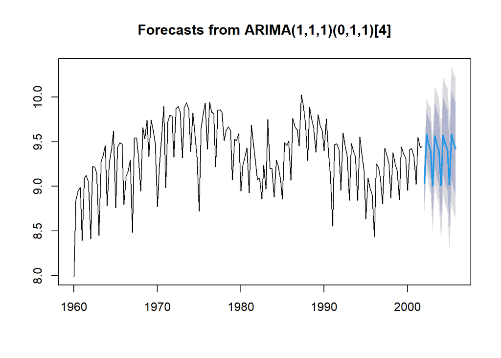

```r
par(mfrow=c(1,1))
plot(pred)
```